# Statistics2, lab 1: 1-way ANOVA

J.F.P. (Richard) Scholtens s2956586

April 25th, 2018

## 1. Load libraries and data

```r
# remove the comments if you don't have these packages yet, run those lines and then comment the lines again. If you don't comment them again, every time you knit the file R will try to install those packages again.
#install.packages("car")
#install.packages("foreign")

library(foreign)
library(car)
mydata = read.spss("lab1_reading.sav", to.data.frame=TRUE)
```

```
## re-encoding from UTF-8
```

```r
# if you have the file lab1_reading.sav in another folder and you are using windows then it should be something as...
#mydata = read.spss("C:/.../reading.sav", to.data.frame=TRUE) # where you need to replace "..." with the folder where the file is located.
# this command produces a warning, which however is not important.
```

## 2. Investigate variable Post3

```r
str(mydata)
```

```
## 'data.frame':    66 obs. of  7 variables:
##  $ Subject: num  1 2 3 4 5 6 7 8 9 10 ...
##  $ Group  : Factor w/ 3 levels "Basal","DRTA",..: 1 1 1 1 1 1 1 1 1 1 ...
##  $ PRE1   : num  4 6 9 12 16 15 14 12 12 8 ...
##  $ PRE2   : num  3 5 4 6 5 13 8 7 3 8 ...
##  $ POST1  : num  5 9 5 8 10 9 12 5 8 7 ...
##  $ POST2  : num  4 5 3 5 9 8 5 5 7 7 ...
##  $ POST3  : num  41 41 43 46 46 45 45 32 33 39 ...
##  - attr(*, "variable.labels")= Named chr  "" "Group" "" "" ...
##   ..- attr(*, "names")= chr  "Subject" "Group" "PRE1" "PRE2" ...
##  - attr(*, "codepage")= int 65001
```

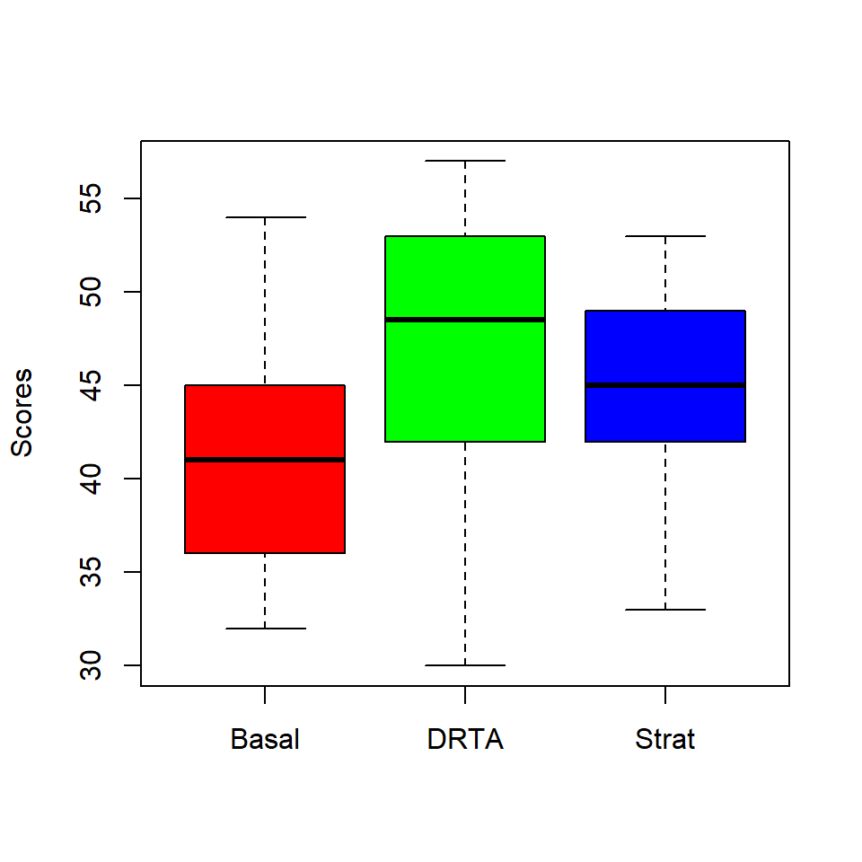

```r
boxplot(mydata$POST3 ~ mydata$Group, ylab = "Scores", col=rainbow(3))
```

## 3. Hypotheses

$H_0$ = There is no difference between the reading methods: “Basal, DRTA and Strat”.

$H_a$ = There is a difference between the reading methods: “Basal, DRTA, and Strat”.

$\mu$ 1 = Basal

$\mu$ 2 = DRTA

$\mu$ 3 = Strat

$H_0$ = $\mu$ 1 = $\mu$ 2 = $\mu$ 3

$H_a$ = Not all of the $\mu$i are equal

## 4. Test normality

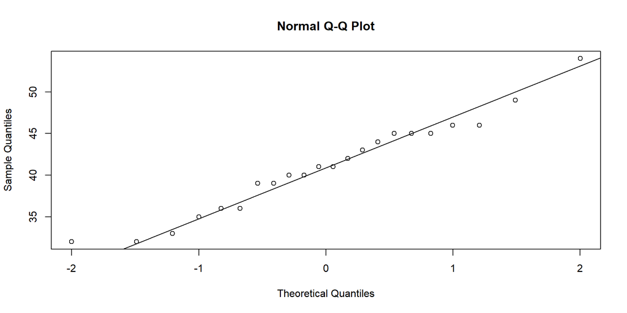

```r
aov <- aov(mydata$POST3 ~ mydata$Group)

qqnorm(mydata$POST3[mydata$Group == 'Basal'])
qqline(mydata$POST3[mydata$Group == 'Basal'])
```

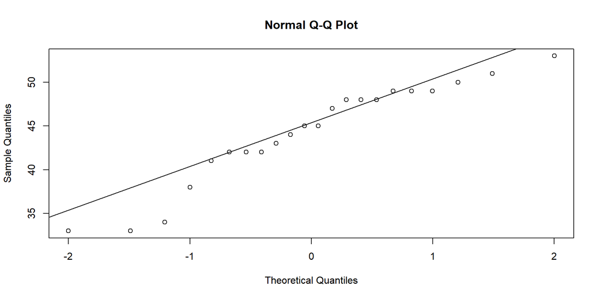

```r
qqnorm(mydata$POST3[mydata$Group == 'Strat'])
qqline(mydata$POST3[mydata$Group == 'Strat'])
```

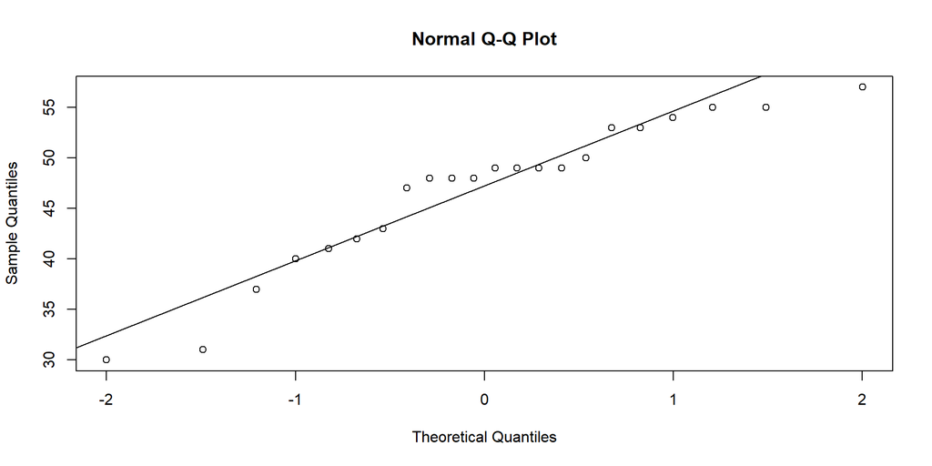

```r
qqnorm(mydata$POST3[mydata$Group == 'DRTA'])
qqline(mydata$POST3[mydata$Group == 'DRTA'])
```

```r
aggregate(mydata$POST3 ~ mydata$Group, data=mydata, function(x) shapiro.test(x)$p.value)
```

```
##   mydata$Group mydata$POST3
## 1        Basal   0.68981678
## 2         DRTA   0.05837370
## 3        Strat   0.08289363
```

$H-0$ = Each group follows normal distribution.

$H-a$ = Each group doesn’t follow normal distribution.

$\alpha$ = 0.05

Shapiro P-value

Basal 0.68981678 DRTA 0.05837370 Strat 0.08289363

If we look at the qqplots we can see that all groups are normally distributed. The p-values of the shapiro-test are higher than the alpha level which means it is normally distributed. Therefor we cannot reject $H-0$.

## 5. Test variance

```r
leveneTest(aov)
```

```
## Levene's Test for Homogeneity of Variance (center = median)
##       Df F value Pr(>F)
## group  2  0.3429  0.711
##       63
```

$H-0$ = The variance in the different groups are equal.

$H-a$ = The variance in the different groups are not equal.

$\alpha$ = 0.05

P-value = 0.711

The p-value is above the significance level. Therefor we do not reject $H-0$. This means all groups are homogeneous.

## 6. Test variance with Hartley’s test, by hand

```r
(basal <- mydata[mydata$Group == "Basal", ]$POST3)
```

```
##  [1] 41 41 43 46 46 45 45 32 33 39 42 45 39 44 36 49 40 35 36 40 54 32
```

```r
(basal_var <- var(basal))
```

```
## [1] 31.75974
```

```r
(count_bas <- length(basal))
```

```
## [1] 22
```

```r
(drta <- mydata[mydata$Group == "DRTA", ]$POST3)
```

```
##  [1] 31 40 48 30 42 48 49 53 48 43 55 55 57 53 37 50 54 41 49 47 49 49
```

```r
(drta_var <- var(drta))
```

```
## [1] 54.58874
```

```r
(count_drta <- length(drta))
```

```
## [1] 22
```

```r
(strat <- mydata[mydata$Group == "Strat", ]$POST3)
```

```
##  [1] 53 47 41 49 43 45 50 48 49 42 38 42 34 48 51 33 44 48 49 33 45 42
```

```r
(strat_var <- var(strat))
```

```
## [1] 33.25541
```

```r
(count_strat <- length(strat))
```

```
## [1] 22
```

```r
(divided <- drta_var/basal_var)
```

```
## [1] 1.718803
```

```r
(nlevel_basal <- nlevels(mydata$Group))
```

```
## [1] 3
```

$H-0$ = The variance in the different groups are equal.

$H-a$ = The variance in the different groups are not equal.

Basal variance = 31.75974

DRTA variance = 54.58874

Strat variance = 33.25541

Dividing the highest variance by the lowest variance.

DRTA variance / Basal variance = F-value

54.58874 / 31.75974 = 1.718803

DF = 21

Number of levels = 3

$\alpha$ = 0.05

Critical value = 2.95 according to http://webspace.ship.edu/pgmarr/Geo441/Tables/Hartley's%20Fmax%20Table.pdf.

The F-value is lower than the critical level. Therefor we do not reject $H-0$.

It gives the same results as the Levene test.

## 7. 1-way ANOVA

```r
summary(aov)
```

```
##              Df Sum Sq Mean Sq F value Pr(>F)
## mydata$Group  2  357.3  178.65   4.481 0.0152 *
## Residuals    63 2511.7   39.87
## ---
## Signif. codes:  0 '***' 0.001 '**' 0.01 '*' 0.05 '.' 0.1 ' ' 1
```

$H_0$ = There is no difference between the reading methods: “Basal, DRTA and Strat”.

$H_a$ = There is a difference between the reading methods: “Basal, DRTA, and Strat”.

p-level = 0.0152

The p-level is lower than the significance level of 0.05. Therefor we reject $H_0$ and accept $H_a$.

This means there is a difference between the reading methods.

## 8. Effect size

Report the effect size in terms of regular R² and adjusted R². The regular R² should be calculated manually.

Formula regular R2:

R^2 = SSG / SST = SSG / (SSG + SSE)

SSG = Sum of Squares Group = 357.3

SSE = Sum of Squares Error = 2511.7

SST = Sum of Squares Total = SSG + SSE = 357.3 + 2511.7 = 2869

```r
summary(lm(formula = mydata$POST3 ~ mydata$Group, data = mydata))
```

```
##
## Call:
## lm(formula = mydata$POST3 ~ mydata$Group, data = mydata)
##
## Residuals:
##     Min      1Q  Median      3Q     Max
## -16.727  -3.614   1.114   3.954  12.954
##
## Coefficients:
##                   Estimate Std. Error t value Pr(>|t|)
## (Intercept)         41.045      1.346  30.490  < 2e-16 ***
## mydata$GroupDRTA     5.682      1.904   2.985  0.00404 **
## mydata$GroupStrat    3.227      1.904   1.695  0.09498 .
## ---
## Signif. codes:  0 '***' 0.001 '**' 0.01 '*' 0.05 '.' 0.1 ' ' 1
##
## Residual standard error: 6.314 on 63 degrees of freedom
## Multiple R-squared:  0.1245, Adjusted R-squared:  0.09675
## F-statistic: 4.481 on 2 and 63 DF,  p-value: 0.01515
```

```r
(SSG <- 357.3)
```

```
## [1] 357.3
```

```r
(SSE <- 2511.7)
```

```
## [1] 2511.7
```

```r
(SST <- SSG + SSE)
```

```
## [1] 2869
```

```r
(R2 <- SSG/SST)
```

```
## [1] 0.1245382
```

Adjusted R-square = 0.09675 Regular R-square = 0.1245382

The effectsize are for both R-squares are around the 0.1 and therefor we can state that the effectsize is small.

## 9. Post-hoc test Bonferroni

```r
pairwise.t.test(x = mydata$POST3, g = mydata$Group, p.adjust.method = "bonferroni")
```

```
##
##  Pairwise comparisons using t tests with pooled SD
##
## data:  mydata$POST3 and mydata$Group
##
##       Basal DRTA
## DRTA  0.012 -
## Strat 0.285 0.606
##
## P value adjustment method: bonferroni
```

The p-level between DRTA and Basal is 0.012. This is below the the significance level of 0.05. There for there is a significant difference in means between DRTA and Basal.

## 10. Post-hoc test TukeyHSD

Another post-hoc test is Tukey Honest Significant Differences (TukeyHSD) covered in Levshina (Section 8.2.6). Run this test. Does the outcome agree with the test carried out in question 9?

```r
TukeyHSD(aov)
```

```
##   Tukey multiple comparisons of means
##     95% family-wise confidence level
##
## Fit: aov(formula = mydata$POST3 ~ mydata$Group)
##
## $`mydata$Group`
##                  diff       lwr       upr     p adj
## DRTA-Basal   5.681818  1.112137 10.251499 0.0111135
## Strat-Basal  3.227273 -1.342408  7.796953 0.2149995
## Strat-DRTA  -2.454545 -7.024226  2.115135 0.4064363
```

The highest difference in means is seen between DRTA and Basal. The Bonferroni outcome states the same. They outcomes agree with eachother.